# Exercise 4 — Aggregated Data and Global Spatial Autocorrelation

BSTA 374 · 17.5 points · Due Wednesday, October 14, 2026, 11:59 pm

Author

Evy · Lehigh University

Published

October 14, 2026

## What this exercise is

Exercises 1–3 ran on data that shipped inside an R package. This one does not. You will work with **real surveillance data** — COVID-19 deaths in the 67 counties of Pennsylvania — and assemble the analysis dataset yourself, the way you would in a health department: a table of counts from one source, county boundaries from another, and a join between them that has to be checked rather than trusted.

From there the exercise follows the sequence of the last two weeks:

1. join and project the data;
2. compute crude rates, **expected counts**, and the **standardized mortality ratio (SMR)**;
3. map the SMR honestly — which, for a ratio, is not the same as mapping a rate;
4. build a spatial weights matrix and ask, with **global Moran’s I**, whether the SMRs are spatially structured or could plausibly be arranged at random.

It is worth 17.5 points and carries more weight than the first two exercises. Start early: Part A is where most of the unexpected problems will be.

**ImportantSubmission**

Render the exercise as a page of your course site and push it to GitHub, as for Exercises 2 and 3. Then submit to Course Site:

- `LASTNAME_FI_Exercise4.qmd` — the source
- the URL of the rendered page on your GitHub Pages site

Example: `DELMELLE_EM_Exercise4.qmd`. Put your name in the document header.

**Due Wednesday, October 14, 2026 at 11:59 pm.** Late work loses 20% per day unless you arrange something with me in advance.

**WarningReproducibility is graded**

Restart R and render from a clean session before you submit. The CSV must be in your repository (put it in a `data/` folder) and be read with a **relative path** — `read_csv("data/...")`, never `C:/Users/...` — or the document will not render on my machine.

## The data

**Counts.** `pa_covid_deaths_2020.csv` is posted on Course Site. It is a subset of the **Johns Hopkins University CSSE COVID-19 Data Repository** (`time_series_covid19_deaths_US.csv`), the source behind the JHU dashboard that was the most widely used COVID-19 tracker in the United States until the project stopped updating in March 2023. The repository compiles counts reported by state health departments — here, the Pennsylvania Department of Health — and attributes deaths to the county of residence.

| Column | Meaning |
| --- | --- |
| `UID`, `FIPS` | JHU identifier; county FIPS code |
| `Admin2` | County name |
| `Province_State` | State |
| `Population` | County population (U.S. Census Bureau 2019 estimate, as carried in the JHU file) |
| `deaths_2020` | Cumulative COVID-19 deaths reported through December 31, 2020 |

Cite the source in your document as: Dong, E., Du, H., & Gardner, L. (2020). An interactive web-based dashboard to track COVID-19 in real time. *The Lancet Infectious Diseases, 20*(5), 533–534, together with the repository URL: https://github.com/CSSEGISandData/COVID-19.

**Boundaries.** County polygons come from the U.S. Census Bureau’s **cartographic boundary files**, downloaded inside your document with the `tigris` package. Install it once, in the console — `install.packages(c("tigris", "ggrepel"))` — not inside the document.

**NoteWhy 2020**

Calendar year 2020 is the first pandemic year and the period before vaccines were available. Treat the population as the population at risk for one year.

```r
library(sf)
library(dplyr)
library(readr)
library(ggplot2)
library(patchwork)
library(leaflet)
library(spdep)
library(ggrepel)            # non-overlapping labels
library(tigris)
options(tigris_use_cache = TRUE)   # download once, then reuse

covid <- read_csv("pa_covid_deaths_2020.csv")
pa    <- counties(state = "PA", cb = TRUE, year = 2020)
```

## Part A — Assemble the dataset (3 points)

1. Inspect both objects. How many rows does `covid` have, and how many polygons does `pa` have? The two numbers differ. Find the rows responsible and say in one sentence what they are and why they cannot be mapped. Covid has 69 rows and pa has 67 polygons. The rows responsible are “Out of PA” and “Unassigned.” These categories represent deaths that were not assigned to a specific county or happened outside of Pennsylvania’ 67 counties, so they cannot be mapped in the state.
2. Identify the column in each object that identifies a county. Show what the values look like in each, and say why they will not match as they stand. In ‘pa’ GEOID identifies each county as a 5 digit identifier, with the first 2 values representing the state (42 for PA), and the next representing the county. For example, 42095 represents Northampton County, where Lehigh University is located. In ‘covid’ FIPS represents each county. FIPS are government issued numerical identifiers that represent geographic areas, and they contain the same numbers as the GEOID column in PA. For example, Northampton county is the five digit identifier 42095. The reason the two columns do not match despite visually looking the same is how they are kept within the data set. The ‘covid’ FIPS data is numerical, while the ‘pa’ GEOID data is stored as a string.
3. Create a join key in `covid` that matches the one in `pa`, then **join the counts onto the polygons**. Show, with code, that every one of the 67 counties received a count — do not just look at the map. To show that all 67 counties received a count, I checked that there were no “NA” indicating something went wrong. I also checked that the data had 67 rows, showing no counties were dropped and that nothing had been duplicated.
4. In two or three sentences: why join the table onto the polygons (`left_join(pa, covid)`) rather than the other way around, and what would an **inner** join have hidden from you if the key had been only partly wrong? A join decides which rows of a table survive, with a left join keeping all of the rows from ‘pa’ and adding on matching rows from ‘covid.’ Because the 67 polygons are what we are studying, those must go in the left surviving table, ensuring all come through the join. A failed match would show up as NA, which is detectable, while the reverse would include all 69 rows of ‘covid,’ including the “Out of PA” and “Unassigned” rows. An inner join on the other hand keeps only the rows that match on both tables which could be an issue if there was a formatting problem in the data, making it seem like some of the counties had no match, because they would be dropped from the table. No NAs would appear so that check would be pointless. Essentially, an inner join could cause problems silently, making me unaware there is something wrong in the data.

**Tip**

Run the obvious join first, `left_join(pa, covid, by = c("GEOID" = "FIPS"))`, and read the error message carefully. It tells you exactly what is wrong. A FIPS code is an **identifier**, not a number: `42001` and `42001.0` are the same number but not the same identifier, and a county such as `01001` in Alabama would lose its leading zero.

### Starting code

```r
# A1
nrow(covid); nrow(pa)
```

```
[1] 69
```

```
[1] 67
```

```r
#rows in the table with no polygon to go to (names are good enough to look) #remove rows with no attachable polygons
anti_join(covid, st_drop_geometry(pa), by = c("Admin2" = "NAME"))
```

```
# A tibble: 2 × 6
       UID  FIPS Admin2     Province_State Population deaths_2020
     <dbl> <dbl> <chr>      <chr>               <dbl>       <dbl>
1 84080042 80042 Out of PA  Pennsylvania            0           0
2 84090042 90042 Unassigned Pennsylvania            0           0
```

```r
# A2 -- what type is each key?
str(covid$FIPS)
```

```
 num [1:69] 42001 42003 42005 42007 42009 ...
```

```r
str(pa$GEOID)
```

```
 chr [1:67] "42033" "42125" "42031" "42097" "42061" "42101" "42049" "42091" ...
```

```r
# A3 -- a five-character, zero-padded text key #make sure data are integers
covid <- covid |>
 mutate(GEOID = sprintf("%05d", as.integer(FIPS)))

pa_covid <- pa |>
 left_join(covid, by = "GEOID")

#left_join(pa, covid, by = c("GEOID" = "FIPS"))

# prove the join worked
sum(is.na(pa_covid$deaths_2020))
```

```
[1] 0
```

```r
nrow(pa_covid)
```

```
[1] 67
```

```r
anyDuplicated(pa_covid$GEOID)
```

```
[1] 0
```

## Part B — Coordinate reference system (1.5 points)

1. What CRS do the Census boundaries arrive in? Geographic or projected? The Census boundaries arrive in NAD83, aka. the North American Datum of 1983 (EPSG:4269), which is longitude and latitude and is therefore geographic; this is confirmed in the return of `st_is_longlat(pa_covid` as TRUE.
2. Transform `pa_covid` to a **projected** CRS appropriate for the whole state, and state its EPSG code. Pennsylvania is split between two State Plane zones (North and South) and two UTM zones, so the obvious choices each cover only part of the state — say what you chose and why it is acceptable for a statewide map. I have chosen to use EPSG code EPSG:5070 which uses the Albers Equal Area Conic map projection. I chose it because preserves area proportion across the whole map and at a state level does not cause much distortion. It can cause distortion on local levels, but because we are looking at the whole of PA it should be minimally distorted. This avoids the issue of the state being split in two by the State PLane zones or the UTM zones.
3. One sentence: which of the operations in this exercise actually depend on the projection, and which do not? The things that need the geometry’s shape or area depend on the projection. In this exercise that includes the static maps and the leaflet map (which uses long/lat). Things such as crude rates, expected counts, SMR, Moran’s I, CI, and queen contiguity do not.

### Starting code

```r
st_crs(pa_covid)$input
```

```
[1] "NAD83"
```

```r
st_crs(pa_covid)$epsg #returns EPSG number
```

```
[1] 4269
```

```r
st_is_longlat(pa_covid) #TRUE= geographic
```

```
[1] TRUE
```

```r
pa_covid <- st_transform(pa_covid, crs="EPSG:5070") #transforms from EPSG:4269 to EPSG:5070
st_is_longlat(pa_covid) #FALSE = projected
```

```
[1] FALSE
```

## Part C — Counts, rates, expected counts, and the SMR (4.5 points)

1. Compute the **crude COVID-19 mortality rate per 100,000** for 2020 in every county. Report the three highest and three lowest. Highest Crude Mortality Rates (high-low):
   1. Mifflin County: 257.9219
   2. Northumberland County: 248.7809
   3. Bedford County: 196.2913 Lowest Crude Mortality Rates (low-high):
   4. Wayne County: 35.04605
   5. Forest County: 41.39644
   6. Greene County: 41.39872
2. Make two quick static maps with `ggplot2`, placed side by side: the **number of deaths** as **proportional symbols**, and the **crude rate** as a choropleth with a sequential, colour-blind-safe palette. Both need a legend title with units. In two or three sentences: why is a count shown with symbols rather than a choropleth, which counties stand out on each map, and why do the two maps tell different stories? The counts are shown as symbols so that the size actually represents something. If they were in a choropleth, it could look like visually that counties that are larger had higher counts, when in actuality they do not. Keeping them as symbols separates the size of the county with the size of the count visually. On the count map the counties of Philadelphia, Delaware, Montgomery, and Bucks stand out because they are large circles and close together and Allegheny stands out because it appears to have a larger count then surrounding counties. On the choropleth map Mifflin and Northumberland stand out because they are the darkest, indicating the largest crude rates. These maps tell different stories because the crude rate takes the large populations of counties such as Philadelphia into account, whereas the count map does not, so it shows larger numbers in more populous counties.
3. Compute the **statewide reference rate** $r = \sum_i O_i / \sum_i P_i$, and from it the **expected count** in each county, $E_i = r \times P_i$. Show that $\sum_i E_i = \sum_i O_i$ and explain in one sentence why this must be so. Statewide reference rate = 125.2149 deaths per 100,000 population `sum(pa_covid$E); sum(pa_covid$deaths_2020)` are equal. The expected rate is calculated using the statewide reference rate times the population, and because we are looking at deaths on a state level, these are equal. Essentially: $r = \sum_i O_i / \sum_i P_i$ can also be worded $\sum_i O_i = r * \sum_i P_i$ and $E_i = r \times P_i$ so therefore $\sum_i E_i = \sum_i O_i$.
4. Compute the **SMR**, $O_i / E_i$.
   1. Interpret the SMR of one county of your choice in a full sentence a county commissioner could understand. For Northampton county the Standardized Mortality Ratio was 1.13, meaning that Northampton county had 13% more deaths than expected compared to the statewide rate: 431 deaths were observed compared to the expected about 382 deaths for if the county had experienced the same rates as PA as a whole.
   2. Divide each county’s crude rate by the statewide rate and compare with the SMR. Explain why they are identical here, and what $E_i$ would have to take into account for the two to differ. *(This is where we are going later in the semester.)* The new rate and the SMR are the same because: $New Rate = Crude Rate/r = (O_i /P_i)/r = O_i /(P_i * r) = O_i /E_i = SMR$ If $E_i$ took into account a factor such as age or something else that changes how vulnerable a people are to dying of COVID, that could make them differ, as it is currently based on population alone. If one county had a much older overall population then these could differ because they would have a much higher expected count of death because older people have a higher risk of dying from COVID and expected counts could be built off of age-specific reference rates.
5. Compute an exact **95% confidence interval** for every SMR (formula below). Compare the intervals for the two or three counties with the **fewest** deaths with those of the counties with the **highest** SMRs. In three or four sentences: what does this tell you about the extreme values on an SMR map? The CI intervals for the counties with the fewest deaths were between 0.74-1.64 away from eachother. The CI intervals for the counties with the highest SMR were between 0.38-0.91 away from eachother. These numbers were calculated by subtracting the lower CI number from the higher CI number, and are simply a representation of how wide of an interval the CI has. The range of CI intervals for the counties with the fewest deaths was much larger than the rand for the counties with the highest SMR. This shows that for low count counties, the SMRs are unstable. This is confirmed by 4 out fo the 5 fewest death counties CI interval crossing through 1, showing that they are not statistically significant. The counties with the highest SMR’s however, all had intervals that excluded 1. This says that when counts are small, extreme values appear by chance and can mean little.

**NoteWhere the confidence interval comes from**

Treat the expected count $E$ as a fixed constant and the observed count as Poisson, $O \sim \text{Poisson}(\mu)$ with $\mu = \text{SMR} \times E$. We first find an exact 95% interval for $\mu$ and then divide both ends by $E$.

The lower bound $\mu_L$ is the value of $\mu$ at which observing $O$ **or more** deaths has probability 0.025; the upper bound $\mu_U$ is the value at which observing $O$ **or fewer** has probability 0.025. Because of the link between the Poisson and chi-square distributions, both have a closed form:

$$\mu_L = \tfrac{1}{2}\,\chi^2_{0.025,\;2O}, \qquad
\mu_U = \tfrac{1}{2}\,\chi^2_{0.975,\;2(O+1)} .$$

Dividing by $E$ gives the interval for the SMR:

$$\left[\ \frac{\chi^2_{0.025,\,2O}}{2E}\ ,\ \ \frac{\chi^2_{0.975,\,2(O+1)}}{2E}\ \right].$$

The upper bound uses $2(O+1)$ degrees of freedom and the lower bound $2O$; that asymmetry is what keeps the interval exact when counts are small. When $O = 0$ the lower bound is 0.

**Worked example.** A county with $O = 4$ and $E = 5.57$ has SMR $= 0.72$ and

```r
qchisq(0.025, 2 * 4)       / (2 * 5.57)   # 0.20
qchisq(0.975, 2 * (4 + 1)) / (2 * 5.57)   # 1.84
poisson.test(4, T = 5.57)$conf.int        # same interval: E acts as the "time base"
```

The familiar normal approximation, $\text{SMR} \times \exp(\pm 1.96/\sqrt{O})$, works for counties with many deaths but breaks down for the smallest ones — which are exactly the counties this question is about — and is undefined when $O = 0$.

### Starting code

```r
# C1
pa_covid <- pa_covid |>
  mutate(crude_rate = 100000 * deaths_2020 / Population)

#find 3 highest crude rates
three_highest <- pa_covid[order(pa_covid$crude_rate, decreasing = TRUE), ][1:3, ]
print(three_highest)
```

```
Simple feature collection with 3 features and 19 fields
Geometry type: MULTIPOLYGON
Dimension:     XY
Bounding box:  xmin: 1449492 ymin: 1987667 xmax: 1630692 ymax: 2180281
Projected CRS: NAD83 / Conus Albers
   STATEFP COUNTYFP COUNTYNS       AFFGEOID GEOID           NAME
53      42      087 01213679 0500000US42087 42087        Mifflin
4       42      097 01209186 0500000US42097 42097 Northumberland
37      42      009 01209171 0500000US42009 42009        Bedford
                NAMELSAD STUSPS   STATE_NAME LSAD      ALAND   AWATER      UID
53        Mifflin County     PA Pennsylvania   06 1064602254  9507394 84042087
4  Northumberland County     PA Pennsylvania   06 1185344304 50674892 84042097
37        Bedford County     PA Pennsylvania   06 2621693106 12005858 84042009
    FIPS         Admin2 Province_State Population deaths_2020
53 42087        Mifflin   Pennsylvania      46138         119
4  42097 Northumberland   Pennsylvania      90843         226
37 42009        Bedford   Pennsylvania      47888          94
                         geometry crude_rate
53 MULTIPOLYGON (((1512789 207...   257.9219
4  MULTIPOLYGON (((1587383 211...   248.7809
37 MULTIPOLYGON (((1452686 198...   196.2913
```

```r
#find 3 lowest crude rates
three_lowest <- pa_covid[order(pa_covid$crude_rate, decreasing = FALSE), ][1:3, ]
print(three_lowest)
```

```
Simple feature collection with 3 features and 19 fields
Geometry type: MULTIPOLYGON
Dimension:     XY
Bounding box:  xmin: 1304925 ymin: 1962636 xmax: 1719365 ymax: 2294525
Projected CRS: NAD83 / Conus Albers
   STATEFP COUNTYFP COUNTYNS       AFFGEOID GEOID   NAME      NAMELSAD STUSPS
23      42      127 01213692 0500000US42127 42127  Wayne  Wayne County     PA
60      42      053 01213669 0500000US42053 42053 Forest Forest County     PA
52      42      059 01214033 0500000US42059 42059 Greene Greene County     PA
     STATE_NAME LSAD      ALAND   AWATER      UID  FIPS Admin2 Province_State
23 Pennsylvania   06 1879734030 64785676 84042127 42127  Wayne   Pennsylvania
60 Pennsylvania   06 1106595595  8369675 84042053 42053 Forest   Pennsylvania
52 Pennsylvania   06 1491658046  5296803 84042059 42059 Greene   Pennsylvania
   Population deaths_2020                       geometry crude_rate
23      51361          18 MULTIPOLYGON (((1691332 220...   35.04605
60       7247           3 MULTIPOLYGON (((1359123 216...   41.39644
52      36233          15 MULTIPOLYGON (((1307743 197...   41.39872
```

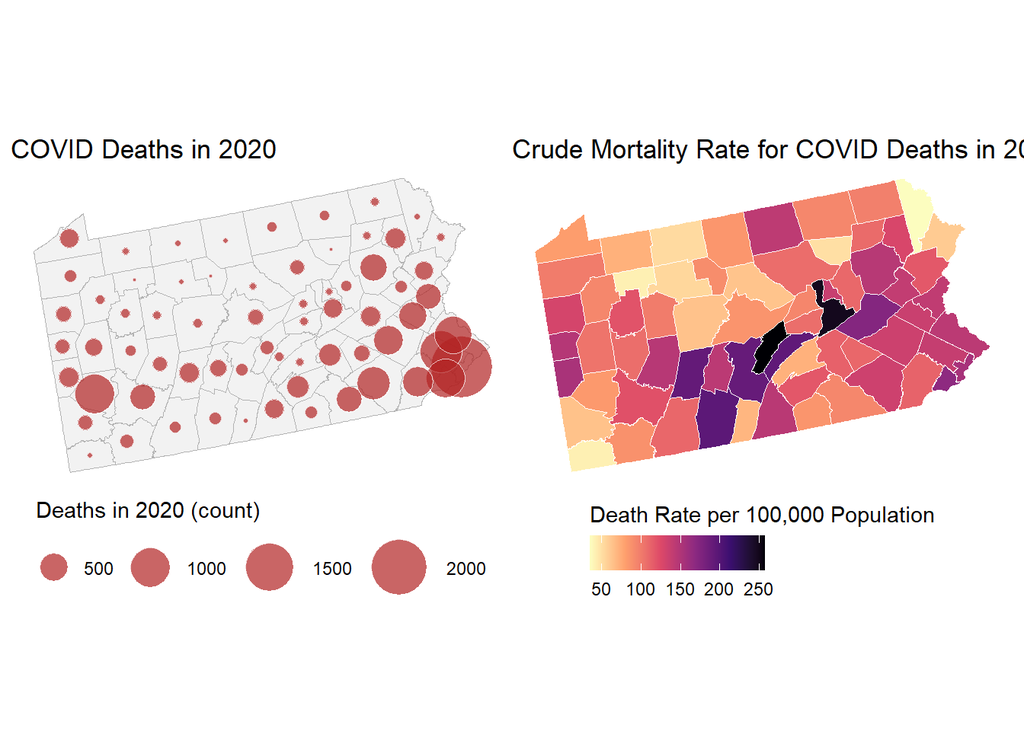

```r
# C2 -- counts as proportional symbols
pts <- st_point_on_surface(pa_covid)        # one point inside each county
p_count <- ggplot() +
  geom_sf(data = pa_covid, fill = "grey95", colour = "grey70", linewidth = 0.15) +
  geom_sf(data = pts, aes(size = deaths_2020),
          shape = 21, fill = "firebrick", colour = "white", alpha = 0.7) +
  scale_size_area(max_size = 14, name = "Deaths in 2020 (count)") +   # area proportional to count
  labs(title = "COVID Deaths in 2020") +
  theme_void() +
  theme(legend.position = "bottom") +
  guides(
    size = guide_legend(
      title.position = "top"))

# rates as a choropleth

p_rate <- ggplot(pa_covid) +
  geom_sf(aes(fill = crude_rate), colour = "white", linewidth = 0.15) +
  scale_fill_viridis_c(option = "magma", direction = -1, name = "Death Rate per 100,000 Population") +
  labs(title = "Crude Mortality Rate for COVID Deaths in 2020") +
  theme_void() +
  theme(legend.position = "bottom") +
  guides(
    fill = guide_colourbar(title.position = "top"))

p_count + p_rate
```

```r
# C3 -- one number for the whole state
r <- sum(pa_covid$deaths_2020) / sum(pa_covid$Population)
r * 100000                         # per 100,000
```

```
[1] 125.2149
```

```r
pa_covid <- pa_covid |>
  mutate(E = r * Population)

sum(pa_covid$E); sum(pa_covid$deaths_2020)
```

```
[1] 16030
```

```
[1] 16030
```

```r
# C4
pa_covid <- pa_covid |>
  mutate(SMR = deaths_2020/E)

summary(pa_covid$SMR)
```

```
   Min. 1st Qu.  Median    Mean 3rd Qu.    Max.
 0.2799  0.6829  0.8786  0.9203  1.1343  2.0598
```

```r
#county crude rate divided by the statewide rate
pa_covid <- pa_covid |>
  mutate(crude_v_state = crude_rate/(r*100000))

#should be TRUE
all.equal(pa_covid$SMR, pa_covid$crude_v_state)
```

```
[1] TRUE
```

```r
# C5 -- exact Poisson interval
pa_covid <- pa_covid |>
  mutate(SMR_lo = qchisq(0.025, 2 * deaths_2020) / (2 * E),
         SMR_hi = qchisq(0.975, 2 * (deaths_2020 + 1)) / (2 * E))

#length of CI
pa_covid <- pa_covid |>
  mutate(CI_length = SMR_hi - SMR_lo)

#compare counties with fewest deaths
pa_covid |>
  st_drop_geometry() |>
  arrange(deaths_2020) |>
  select(NAME, Population, deaths_2020, E, SMR, SMR_lo, SMR_hi, CI_length) |>
  head(5)
```

```
      NAME Population deaths_2020         E       SMR     SMR_lo    SMR_hi
1 Sullivan       6066           3  7.595537 0.3949688 0.08145206 1.1542664
2   Forest       7247           3  9.074325 0.3306031 0.06817831 0.9661626
3  Cameron       4447           4  5.568307 0.7183511 0.19572651 1.8392642
4   Fulton      14530          10 18.193728 0.5496400 0.26357373 1.0108075
5   Potter      16526          14 20.693017 0.6765567 0.36987986 1.1351472
  CI_length
1 1.0728143
2 0.8979842
3 1.6435377
4 0.7472338
5 0.7652674
```

```r
#compare counties with highest SMR
pa_covid |>
  st_drop_geometry() |>
  arrange(desc(SMR)) |>
  select(NAME, Population, deaths_2020, E, SMR, SMR_lo, SMR_hi, CI_length) |>
  head(5)
```

```
            NAME Population deaths_2020         E      SMR   SMR_lo   SMR_hi
1        Mifflin      46138         119  57.77166 2.059834 1.706401 2.464898
2 Northumberland      90843         226 113.74899 1.986831 1.736223 2.263451
3        Bedford      47888          94  59.96292 1.567635 1.266809 1.918389
4        Juniata      24763          48  31.00697 1.548039 1.141402 2.052475
5        Cambria     130192         250 163.01981 1.533556 1.349333 1.735910
  CI_length
1 0.7584966
2 0.5272286
3 0.6515798
4 0.9110734
5 0.3865770
```

## Part D — Mapping a ratio (3.5 points)

In Exercise 1 a sequential palette was the right choice for a rate. An SMR is different: it is a ratio with a **meaningful reference value of 1**, and it is **multiplicative** — an SMR of 2 is as far above expected as 0.5 is below it.

1. Map the SMR as an interactive **`leaflet`** map with a **diverging palette centred on 1** and **class breaks you set yourself**. Choose breaks that are symmetric on the ratio scale, and make the class around 1 read as “about as expected”. Justify the palette and the breaks in three or four sentences. I chose the breaks based on the idea that SMR is multiplicative. Zero-0.5 is less than half of expected deaths, 0.5-0.67 is well below expected deaths, 0.67-0.8 is below expected deaths, 0.8 to 1.25 range represents about what is expected for deaths, 1.25-1.5 represents a bit above expected deaths, 1.5-2 is well above expected deaths, and 2 and up is more than double expected deaths. The red blue palette shows this as well, with darker blues deepening to show less than expected deaths, closer to white showing expected deaths, and deeper reds showing more than expected deaths. It is also color blind safe. These choices both work together to show what is important: which direction a county diverges from the reference value of 1. That is important because it represents if the county is doing better or worse than expected, and can indicate what counties may need interventions.
2. Your SMR map meets the standards from Exercise 1 — legend title with units or meaning, thin boundaries, colour-blind-safe palette — and in addition:
   - a **source line** on the map naming the data and the year;
   - a **popup** for each county giving the observed and expected deaths, the SMR, and its 95% interval from C5. This is what makes an interactive map worth having: the reader can check how much evidence stands behind a colour.

**Warning`leaflet` wants longitude and latitude**

Web maps are drawn on a Web Mercator basemap and expect coordinates in **EPSG:4326**. Your `pa_covid` is now projected (Part B), so give `leaflet` a transformed **copy**, `st_transform(pa_covid, 4326)`, and keep the projected object for everything else. Handing it projected coordinates is the most common reason for a blank `leaflet` map.

**TipWhat earns full marks here**

Breaks that follow from what an SMR *means*, not from the distribution of the values. A student who can explain why 0.67 and 1.5 belong in the same break set understands the variable.

### Starting code

```r
pa_wgs <- st_transform(pa_covid, 4326)      # leaflet needs lon/lat

# D1 -- breaks symmetric on the ratio scale: 1/x and x
brks <- c(0, 0.5, 0.67, 0.8, 1.25, 1.5, 2, Inf) #0, 1/2, 1/1.5, 1/1.25, 1.25, 1.5, 2

pal <- colorBin("RdBu", domain = pa_wgs$SMR, bins = brks,
                reverse = TRUE)             # red = high

leaflet(pa_wgs) |>
  addTiles() |>                               # OpenStreetMap basemap
  addPolygons(
    fillColor = ~pal(SMR), fillOpacity = 0.8,
    color = "white", weight = 0.6,          # thin boundaries
    label = ~NAME,                          # shown on hover
    popup = ~sprintf("<b>%s County</b><br>Observed: %d<br>Expected: %.1f<br>SMR: %.2f (95%% CI %.2f-%.2f)",
                     NAME, deaths_2020, E, SMR, SMR_lo, SMR_hi),
    highlightOptions = highlightOptions(weight = 2, color = "black",
                                        bringToFront = TRUE)
  ) |>
  addLegend(pal = pal, values = ~SMR, opacity = 0.8,
            title = "SMR 2020 (observed/expected)", labFormat = labelFormat(digits = 2)) |>
  addControl(html = "<small>Data: JHU CSSE COVID-19 repository (Dong, Du &amp; Gardner 2020),
          deaths through 31 Dec 2020. Population: U.S. Census Bureau 2019.
          Boundaries: U.S. Census Bureau, 2020.</small>",
  position = "bottomleft")   # source line
```

[interactive chart not shown]

**Note**

A `leaflet` map is an HTML widget: it appears in the rendered page on your GitHub Pages site, which is where I grade it. It will not appear in a PDF.

## Part E — Spatial weights and global Moran’s I (4 points)

### Starting code

```r
# E1
nb <- poly2nb(pa_covid, queen = TRUE)
summary(nb)
```

```
Neighbour list object:
Number of regions: 67
Number of nonzero links: 342
Percentage nonzero weights: 7.618623
Average number of links: 5.104478
Link number distribution:

 2  3  4  5  6  7  8  9
 3  7 14 18 15  3  5  2
3 least connected regions:
7 21 52 with 2 links
2 most connected regions:
4 67 with 9 links
```

```r
card(nb) |> range() #gives range of # of neighbors
```

```
[1] 2 9
```

```r
any(card(nb) == 0) #FALSE means none are alone
```

```
[1] FALSE
```

```r
# E2
lw <- nb2listw(nb, style = "W")

# E3 -- shuffle the SMRs across counties 999 times
set.seed(374)
mc <- moran.mc(pa_covid$SMR, lw, nsim = 999)
mc
```

```
    Monte-Carlo simulation of Moran I

data:  pa_covid$SMR
weights: lw
number of simulations + 1: 1000

statistic = 0.28933, observed rank = 1000, p-value = 0.001
alternative hypothesis: greater
```

```r
-1 / (nrow(pa_covid) - 1)          # expectation under the null
```

```
[1] -0.01515152
```

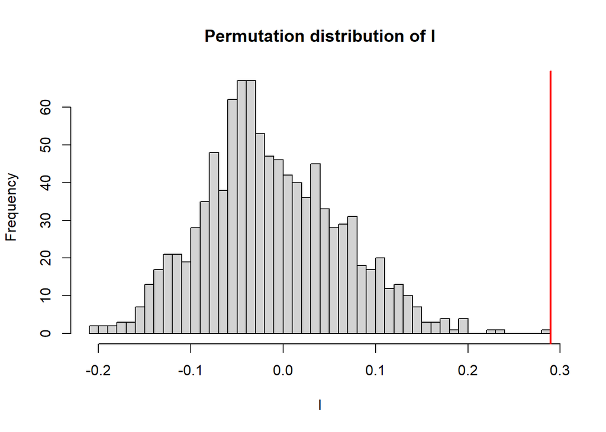

```r
hist(mc$res, breaks = 40, main = "Permutation distribution of I", xlab = "I")
abline(v = mc$statistic, col = "red", lwd = 2)
```

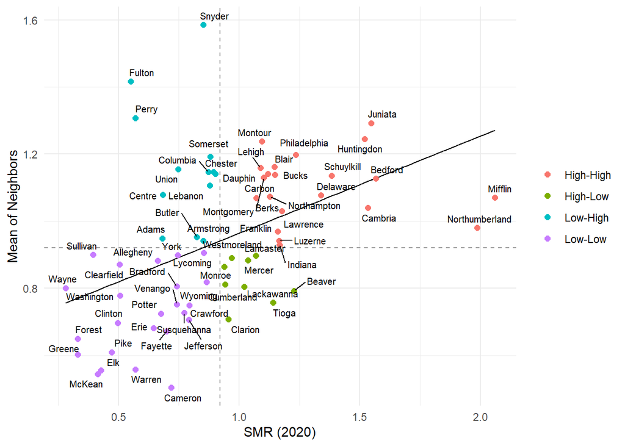

```r
# E4 -- moran.plot() labels only influential points; build it in ggplot2
mp_df <- pa_covid |>
  st_drop_geometry() |>
  mutate(lag_SMR = lag.listw(lw, SMR),          # mean SMR of neighbours
         quad = case_when(
           SMR >= mean(SMR) & lag_SMR >= mean(SMR) ~ "High-High",
           SMR <  mean(SMR) & lag_SMR <  mean(SMR) ~ "Low-Low",
           SMR >= mean(SMR) & lag_SMR <  mean(SMR) ~ "High-Low",
           TRUE                                    ~ "Low-High"))

ggplot(mp_df, aes(SMR, lag_SMR)) +
  geom_hline(yintercept = mean(mp_df$SMR), linetype = 2, colour = "grey60") +
  geom_vline(xintercept = mean(mp_df$SMR), linetype = 2, colour = "grey60") +
  geom_smooth(method = "lm", se = FALSE, colour = "black", linewidth = 0.5) +
  geom_point(aes(colour = quad), size = 2) +
  geom_text_repel(aes(label = NAME), size = 2.6, max.overlaps = Inf) +   # every county
  labs(x = "SMR (2020)", y = "Mean of Neighbors", colour = NULL) +
  theme_minimal()
```

```r
table(mp_df$quad)
```

```
High-High  High-Low  Low-High   Low-Low
       21         9        13        24
```

## Part F — Reproducibility and AI use (1 point)

1. The page renders from a clean session and is live on your GitHub Pages site.
2. End the document with an **AI use note**: which tools, what for, at which stage. Two or three sentences.

   AI use: I used Claude at multiple stages in this exercise. I used it to interpret questions I was confused on, recommend the top few options for code choices I had to make, and to check my work at the end.

## Rubric

| Part | What is assessed | Points |
| --- | --- | --- |
| **A** | Mismatched rows found and explained; key built as text; join verified with code; left vs inner join explained | 3 |
| **B** | Correct projected CRS, stated and justified | 1.5 |
| **C** | Crude rates; count and rate maps compared; reference rate, expected counts and SMR correct; SMR interpreted; small-numbers argument made with intervals | 4.5 |
| **D** | Diverging leaflet map centred on 1 with defended breaks; standards, source line and popup | 3.5 |
| **E** | Weights built and described; Moran’s I by permutation, null hypothesis stated and interpreted; scatterplot read | 4 |
| **F** | Renders from a clean session; published; AI use note | 1 |
|  | **Total** | **17.5** |

Writing counts for roughly 10% of the mark within each part. A submission that is all code and no sentences cannot score above about 60%.

## Getting help

- Moraga §5.1–5.2 (expected counts and SMR) and §5.5 (neighbourhood matrices in `spdep`).
- The `spdep` vignette on neighbour objects: `vignette("nb", package = "spdep")`.
- `?tigris::counties` if the download fails; the same boundaries can be downloaded by hand from the Census Bureau’s cartographic boundary page.
- Office hours, or email me with the code and the exact error message. I am travelling on October 13; email is the fastest route that week.